# Chapter5

Zhang Chen

7/23/2018

```r
library(rethinking)
```

# Easy

## 5E1

2, 3, and 4

## 5E2

Animal diversity = a + b1 x latitude + b2 x plant diversity

## 5E3

Time to PhD degree = a0 + b0 x amount of funding

Time to PhD degree = a1 + b1 x size of laboratory

Time to PhD degree = a2 + b2 x amount of funding + b3 x size of laboratory

b0 and b1 should be around 0; b2 and b3 should be larger than 0.

## 5E4

1, 3, and 5

# Medium

## 5M1

```r
N <- 100
x_real <- rnorm(N)
x_spur <- rnorm(N, mean=x_real)
y <- rnorm(N, mean=x_real)
d <- data.frame(y = y, x_real=x_real, x_spur=x_spur)

lm(y ~ x_real, data=d)
```

```
##
## Call:
## lm(formula = y ~ x_real, data = d)
##
## Coefficients:
## (Intercept)       x_real
##      0.1124       0.7893
```

```r
lm(y ~ x_spur, data=d)
```

```
##
## Call:
## lm(formula = y ~ x_spur, data = d)
##
## Coefficients:
## (Intercept)       x_spur
##      0.1543       0.4721
```

```r
lm(y ~ x_spur + x_real, data=d)
```

```
##
## Call:
## lm(formula = y ~ x_spur + x_real, data = d)
##
## Coefficients:
## (Intercept)       x_spur       x_real
##     0.10810      0.09772      0.68242
```

## 5M2

```r
N   <- 100
rho <- 0.7
x1 <- rnorm(N)
x2 <- rnorm(N, rho*x1, sqrt(1-rho^2))
y  <- rnorm(N, mean=x1-x2)
d  <- data.frame(y=y, x1=x1, x2=x2)

lm(y ~ x1, data=d)
```

```
##
## Call:
## lm(formula = y ~ x1, data = d)
##
## Coefficients:
## (Intercept)           x1
##     -0.2391       0.3208
```

```r
lm(y ~ x2, data=d)
```

```
##
## Call:
## lm(formula = y ~ x2, data = d)
##
## Coefficients:
## (Intercept)           x2
##     -0.2684      -0.2815
```

```r
lm(y ~ x1 + x2, data=d)
```

```
##
## Call:
## lm(formula = y ~ x1 + x2, data = d)
##
## Coefficients:
## (Intercept)           x1           x2
##     -0.1469       0.9085      -0.8832
```

## 5M3

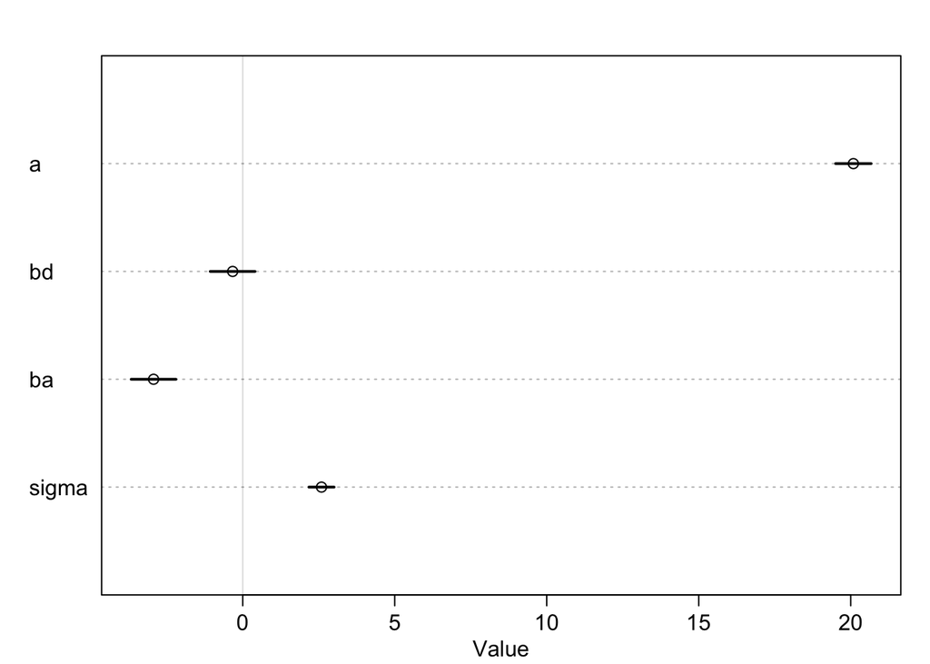

```r
data("WaffleDivorce")
d <- WaffleDivorce

d$MedianAgeMarriage.s <- scale(d$MedianAgeMarriage)
d$Divorce.s <- scale(d$Divorce)

m.5M3 <- map(
  alist(
    Marriage ~ dnorm(mu, sigma),
    mu <- a+bd*Divorce.s+ba*MedianAgeMarriage.s,
    a ~ dnorm(0, 10),
    bd ~ dnorm(0, 10),
    ba ~ dnorm(0, 10),
    sigma ~ dunif(0, 50)
  ),
  data=d)

plot(precis(m.5M3))
```

## 5M4

Mormon population by state information retrieved from https://www.worldatlas.com/articles/mormon-population-by-state.html

```r
LDS <- read.csv("LDS.csv", header = TRUE)
LDS <- LDS[c("State", "Mormon.Percent")]
names(LDS) <- c("Location", "Mormon.Percent")
d <- merge(d, LDS, by="Location")

d$Marriage.s <- scale(d$Marriage)
d$Mormon.Percent.s <- scale(d$Mormon.Percent)

m.5M4 <- map(
  alist(
    Divorce ~ dnorm(mu, sigma),
    mu <- a + ba*MedianAgeMarriage.s + br*Marriage.s + bm*Mormon.Percent.s,
    a ~ dnorm(0, 10),
    ba ~ dnorm(0, 10),
    br ~ dnorm(0, 10),
    bm ~ dnorm(0, 10),
    sigma ~ dunif(0, 50)
  ),
  data=d)

precis(m.5M4)
```

```
##        Mean StdDev  5.5% 94.5%
## a      9.68   0.19  9.38  9.99
## ba    -1.38   0.28 -1.82 -0.93
## br     0.01   0.29 -0.45  0.47
## bm    -0.62   0.23 -0.99 -0.26
## sigma  1.34   0.13  1.13  1.55
```

```r
postcheck(m.5M4)
```

```
## [ 100 / 1000 ]
[ 200 / 1000 ]
[ 300 / 1000 ]
[ 400 / 1000 ]
[ 500 / 1000 ]
[ 600 / 1000 ]
[ 700 / 1000 ]
[ 800 / 1000 ]
[ 900 / 1000 ]
[ 1000 / 1000 ]
## [ 100 / 1000 ]
[ 200 / 1000 ]
[ 300 / 1000 ]
[ 400 / 1000 ]
[ 500 / 1000 ]
[ 600 / 1000 ]
[ 700 / 1000 ]
[ 800 / 1000 ]
[ 900 / 1000 ]
[ 1000 / 1000 ]
```

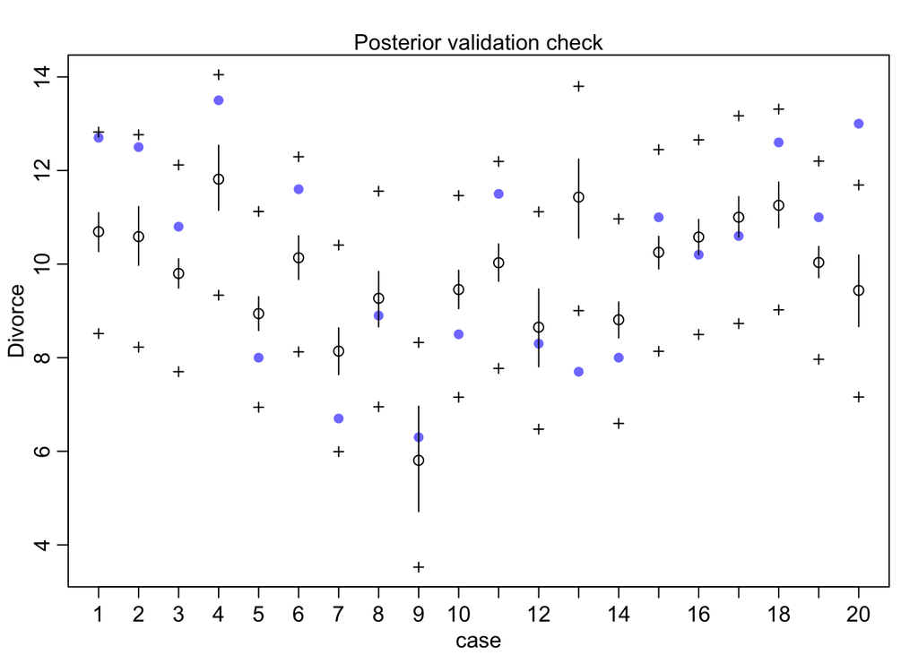

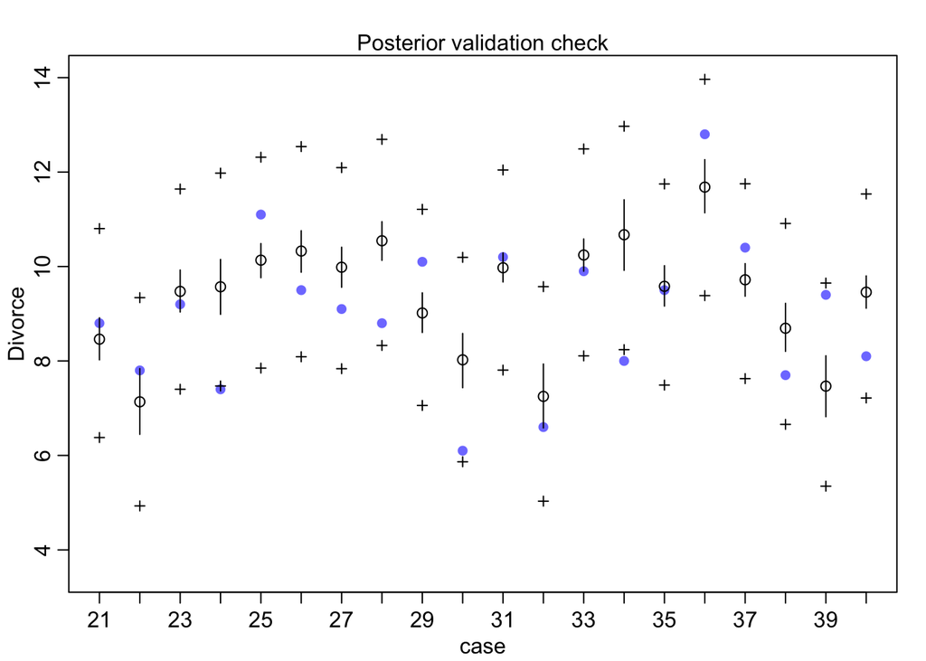

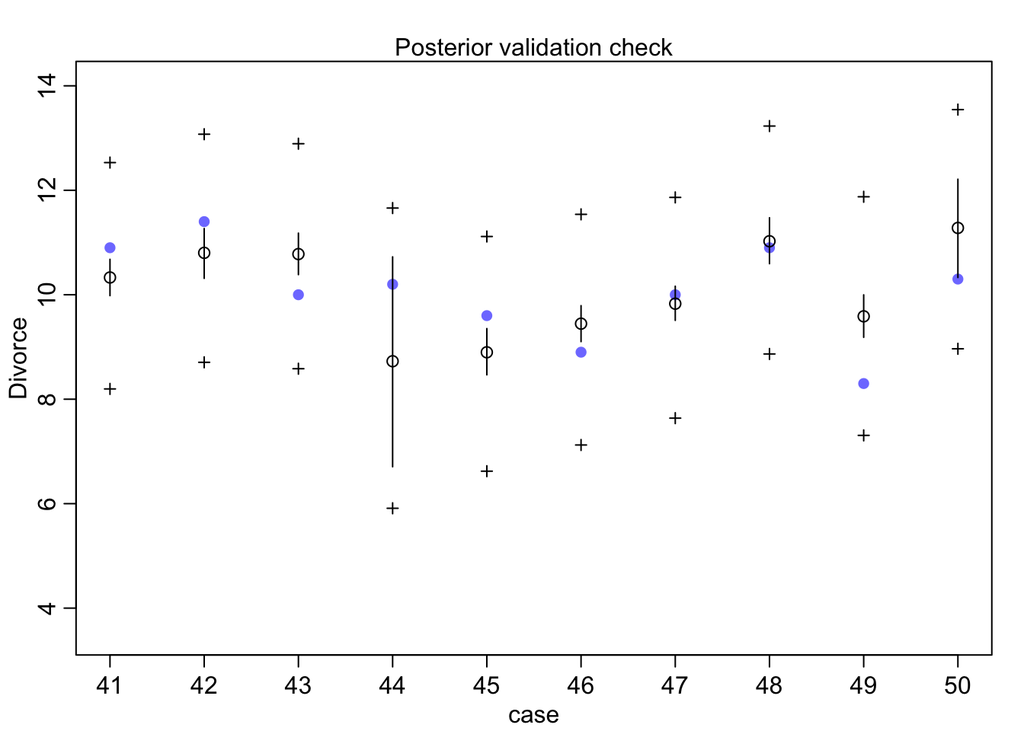

# Hard

## 5H1

```r
data("foxes")
d <- foxes
str(d)
```

```
## 'data.frame':    116 obs. of  5 variables:
##  $ group    : int  1 1 2 2 3 3 4 4 5 5 ...
##  $ avgfood  : num  0.37 0.37 0.53 0.53 0.49 0.49 0.45 0.45 0.74 0.74 ...
##  $ groupsize: int  2 2 2 2 2 2 2 2 3 3 ...
##  $ area     : num  1.09 1.09 2.05 2.05 2.12 2.12 1.29 1.29 3.78 3.78 ...
##  $ weight   : num  5.02 2.84 5.33 6.07 5.85 3.25 4.53 4.09 6.13 5.59 ...
```

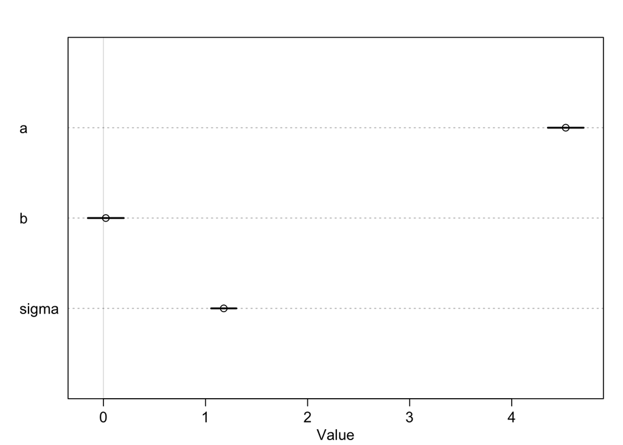

```r
# Predict body weight using territory size
d$area.s <- scale(d$area)

m.5H1.1 <- map(
  alist(
    weight ~ dnorm(mu, sigma),
    mu <- a+b*area.s,
    a ~ dnorm(0, 10),
    b ~ dnorm(0, 10),
    sigma ~ dunif(0, 50)
  ),
  data=d)

plot(precis(m.5H1.1))
```

```r
area.seq <- seq(from=-3, to=3, length.out=100)
mu <- link(m.5H1.1, data=data.frame(area.s=area.seq))
```

```
## [ 100 / 1000 ]
[ 200 / 1000 ]
[ 300 / 1000 ]
[ 400 / 1000 ]
[ 500 / 1000 ]
[ 600 / 1000 ]
[ 700 / 1000 ]
[ 800 / 1000 ]
[ 900 / 1000 ]
[ 1000 / 1000 ]
```

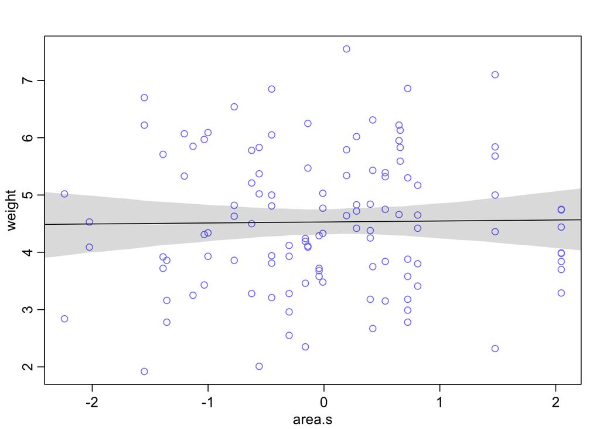

```r
mu.mean <- apply(mu, 2, mean)
mu.PI   <- apply(mu, 2, PI, prob=0.95)

plot(weight ~ area.s, data=d, col=rangi2)
lines(area.seq, mu.mean)
shade(mu.PI, area.seq)
```

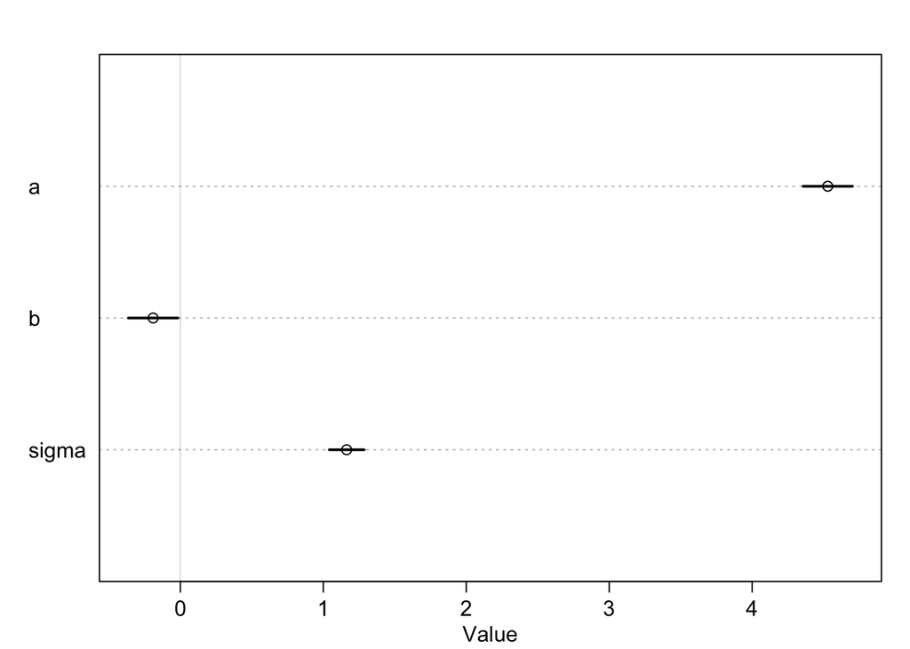

```r
# Predict body weight using group size
d$groupsize.s <- scale(d$groupsize)

m.5H1.2 <- map(
  alist(
    weight ~ dnorm(mu, sigma),
    mu <- a+b*groupsize.s,
    a ~ dnorm(0, 10),
    b ~ dnorm(0, 10),
    sigma ~ dunif(0, 50)
  ),
  data=d)

plot(precis(m.5H1.2))
```

```r
groupsize.seq <- seq(from=-2, to=3, length.out=100)
mu <- link(m.5H1.2, data=data.frame(groupsize.s=groupsize.seq))
```

```
## [ 100 / 1000 ]
[ 200 / 1000 ]
[ 300 / 1000 ]
[ 400 / 1000 ]
[ 500 / 1000 ]
[ 600 / 1000 ]
[ 700 / 1000 ]
[ 800 / 1000 ]
[ 900 / 1000 ]
[ 1000 / 1000 ]
```

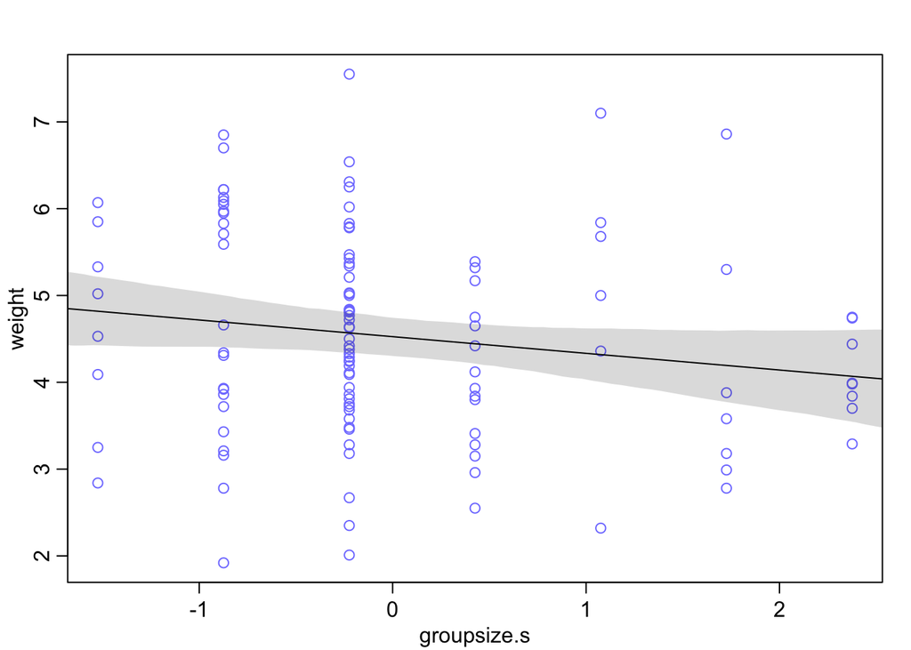

```r
mu.mean <- apply(mu, 2, mean)
mu.PI   <- apply(mu, 2, PI, prob=0.95)

plot(weight ~ groupsize.s, data=d, col=rangi2)
lines(groupsize.seq, mu.mean)
shade(mu.PI, groupsize.seq)
```

## 5H2

```r
m.5H2 <- map(
  alist(
    weight ~ dnorm(mu, sigma),
    mu <- a+bt*area.s+bg*groupsize.s,
    a ~ dnorm(0, 10),
    bt ~ dnorm(0, 10),
    bg ~ dnorm(0, 10),
    sigma ~ dunif(0, 50)
  ),
  data=d)

precis(m.5H2)
```

```
##        Mean StdDev  5.5% 94.5%
## a      4.53   0.10  4.36  4.70
## bt     0.57   0.19  0.28  0.87
## bg    -0.67   0.19 -0.96 -0.37
## sigma  1.12   0.07  1.00  1.24
```

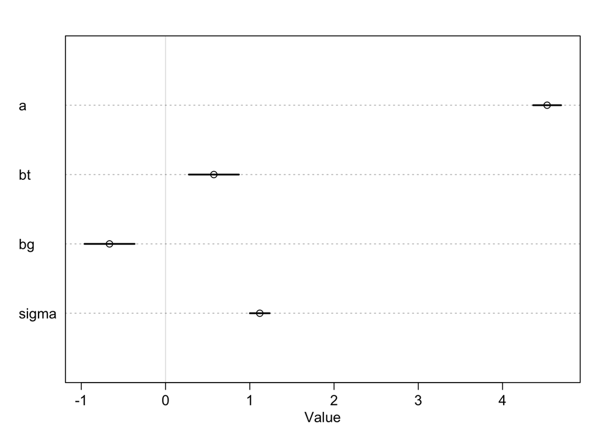

```r
plot(precis(m.5H2))
```

```r
# Counterfactual plot: hold territory size at its mean
pred_data <- data.frame(area.s=0, groupsize.s=groupsize.seq)
mu <- link(m.5H2, data=pred_data)
```

```
## [ 100 / 1000 ]
[ 200 / 1000 ]
[ 300 / 1000 ]
[ 400 / 1000 ]
[ 500 / 1000 ]
[ 600 / 1000 ]
[ 700 / 1000 ]
[ 800 / 1000 ]
[ 900 / 1000 ]
[ 1000 / 1000 ]
```

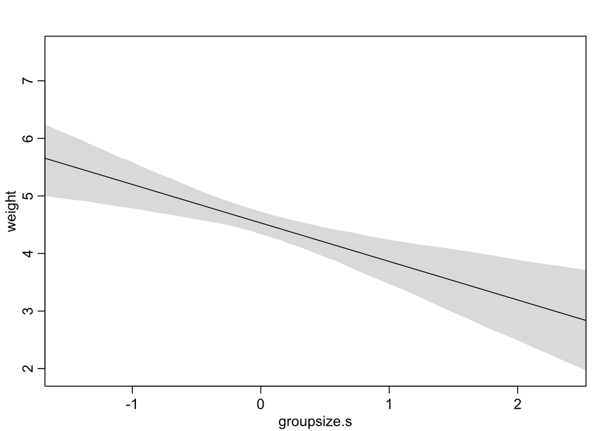

```r
mu.mean <- apply(mu, 2, mean)
mu.PI   <- apply(mu, 2, PI, prob=0.95)

plot(weight ~ groupsize.s, data=d, type="n")
lines(groupsize.seq, mu.mean)
shade(mu.PI, groupsize.seq)
```

```r
# Counterfactual plot: hold group size at its mean
pred_data <- data.frame(area.s=area.seq, groupsize.s=0)
mu <- link(m.5H2, data=pred_data)
```

```
## [ 100 / 1000 ]
[ 200 / 1000 ]
[ 300 / 1000 ]
[ 400 / 1000 ]
[ 500 / 1000 ]
[ 600 / 1000 ]
[ 700 / 1000 ]
[ 800 / 1000 ]
[ 900 / 1000 ]
[ 1000 / 1000 ]
```

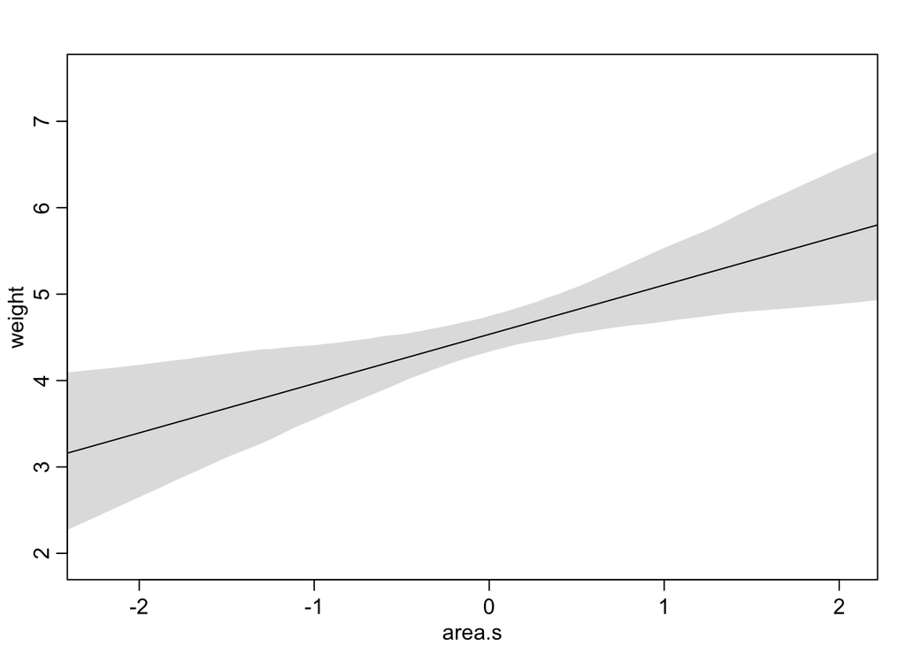

```r
mu.mean <- apply(mu, 2, mean)
mu.PI   <- apply(mu, 2, PI, prob=0.95)

plot(weight ~ area.s, data=d, type="n")
lines(area.seq, mu.mean)
shade(mu.PI, area.seq)
```

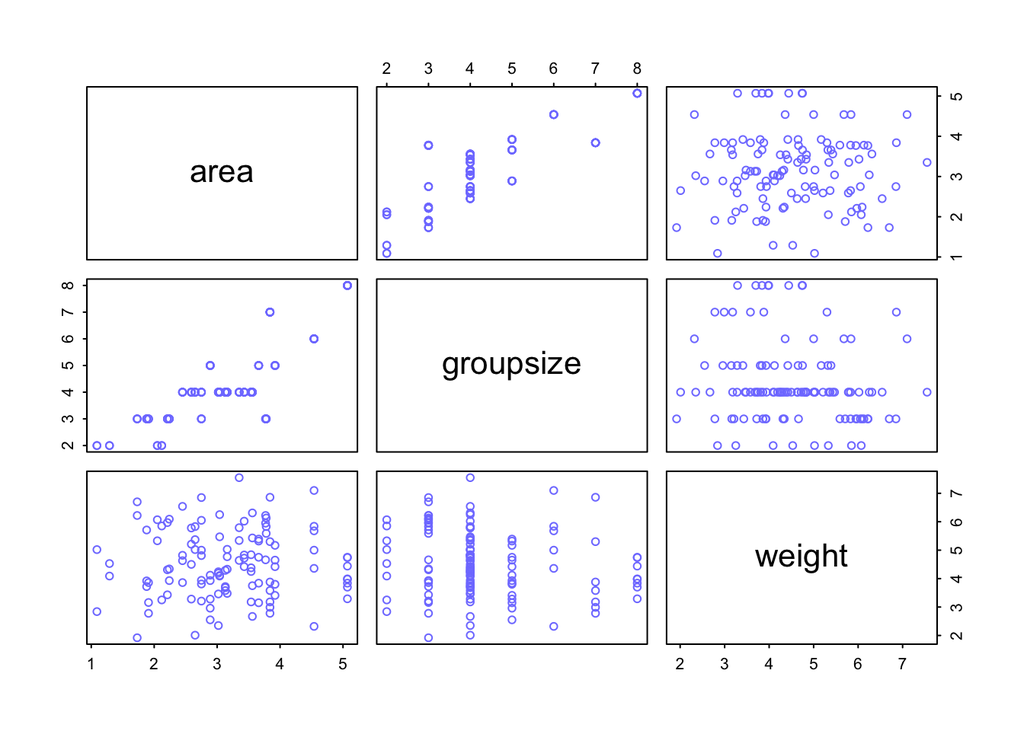

```r
pairs(d[c("area", "groupsize", "weight")], col=rangi2)
```

## 5H3

```r
# Model 1
d$avgfood.s <- scale(d$avgfood)

m.5H3.1 <- map(
  alist(
    weight ~ dnorm(mu, sigma),
    mu <- a+bf*avgfood.s+bg*groupsize.s,
    c(a, bf, bg) ~ dnorm(0, 10),
    sigma ~ dunif(0, 50)
  ),
  data=d)

precis(m.5H3.1)
```

```
##        Mean StdDev  5.5% 94.5%
## a      4.53   0.10  4.36  4.69
## bf     0.76   0.24  0.37  1.14
## bg    -0.87   0.24 -1.26 -0.49
## sigma  1.12   0.07  1.00  1.23
```

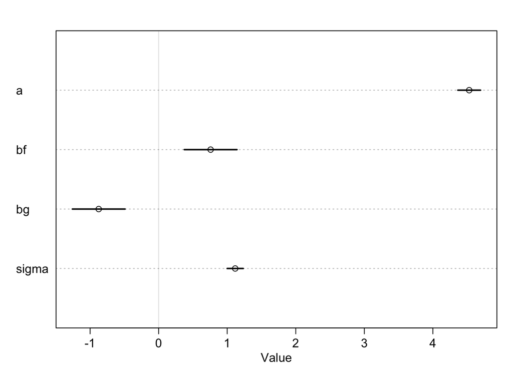

```r
plot(precis(m.5H3.1))
```

```r
# Model 2
m.5H3.2 <- map(
  alist(
    weight ~ dnorm(mu, sigma),
    mu <- a+bf*avgfood.s+bg*groupsize.s+bt*area.s,
    c(a, bf, bg, bt) ~ dnorm(0, 10),
    sigma ~ dunif(0, 50)
  ),
  data=d)

precis(m.5H3.2)
```

```
##        Mean StdDev  5.5% 94.5%
## a      4.53   0.10  4.37  4.69
## bf     0.50   0.29  0.04  0.96
## bg    -0.93   0.24 -1.32 -0.55
## bt     0.36   0.22  0.00  0.71
## sigma  1.10   0.07  0.99  1.22
```

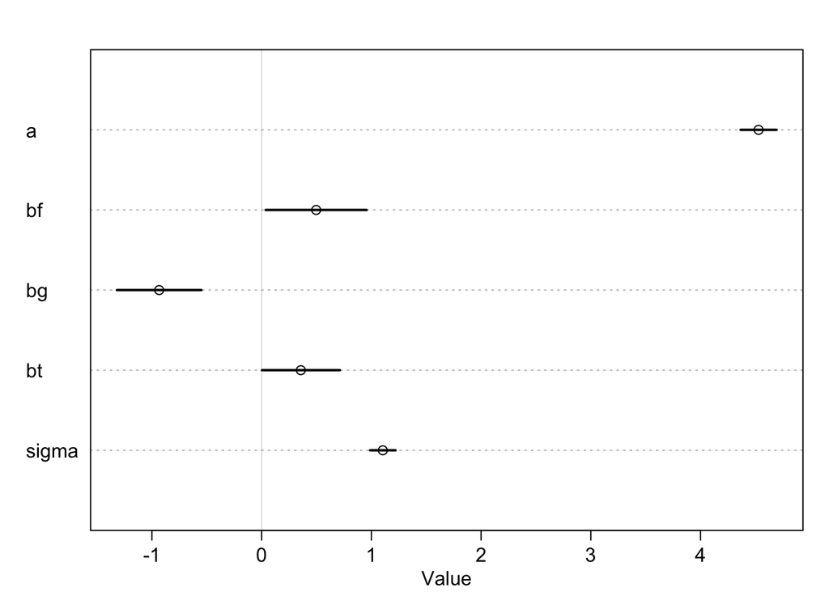

```r
plot(precis(m.5H3.2))
```

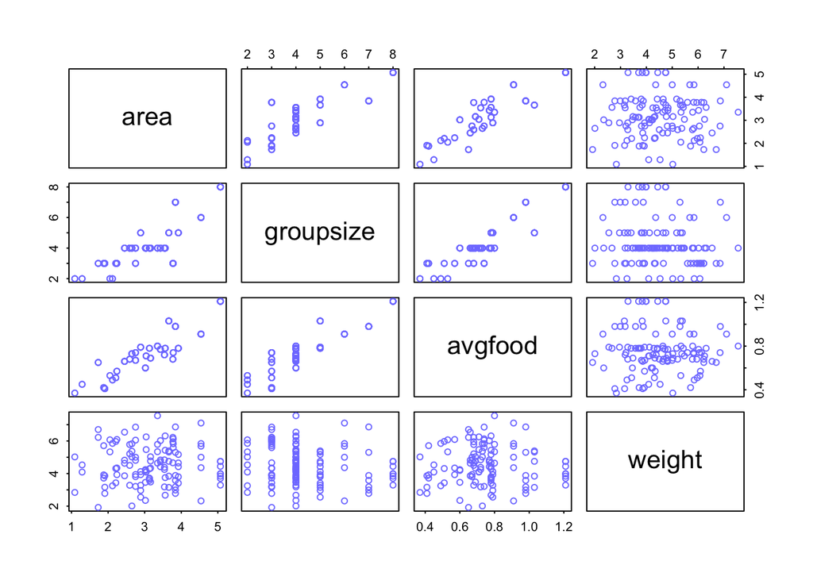

```r
pairs(d[c("area", "groupsize", "avgfood", "weight")], col=rangi2)
```

1. *avgfood* is a better predictor of body weight. Both when *avgfood* and *area* are included in separate models or in one model together, the coefficient for *avgfood* is larger. Also when thinking about the underlying causal mechanisms, it seems more likely that the higher the average amount of food available in an area, the more foods foxes will have access to, and more consumption leads to higher body weight.
2. This is because *avgfood* and *area* are very strongly positively correlated. *Multicollinearity* may have influenced the results here.